# Chicago offsets

This includes all the steps that we did to process the data, the last section is the regressions, but there may be some interesting tidbits along the way. I’m happy to go over this with anyone. I even have a song out regression.

We want to use TidyCensus to grab the following sets of variables for Illinois:

B03002… - population and race by Hispanic origin variables  
B19013_001 - median income  
B17020_001 - poverty population  
B17020_002 - below poverty

We created a list (aka vector) with the variables and grabbed the data from the 2019 5-year ACS for all the ZIP code tabulation areas in Illinois:

```r
load("jlworking.RData")
library(tidycensus)
```

```r
ilvars <- c("B03002_001", "B03002_002", "B03002_003", "B03002_004", "B03002_005", "B03002_006", "B03002_007", "B03002_008","B03002_009", "B03002_012","B19013_001","B17020_001","B17020_002")


ilzcta <- get_acs(geography = "zcta",
              variables = ilvars,
              state = "IL",
              year = 2019)
head(ilzcta)
```

```
## # A tibble: 6 x 5
##   GEOID NAME        variable   estimate   moe
##   <chr> <chr>       <chr>         <dbl> <dbl>
## 1 60002 ZCTA5 60002 B03002_001    24058   373
## 2 60002 ZCTA5 60002 B03002_002    22407   478
## 3 60002 ZCTA5 60002 B03002_003    20816   624
## 4 60002 ZCTA5 60002 B03002_004      508   418
## 5 60002 ZCTA5 60002 B03002_005        5     7
## 6 60002 ZCTA5 60002 B03002_006      339   135
```

Because the data comes from TidyCensus in a long list, we pivot_wider to put the data into columns:

```
## # A tibble: 6 x 28
##   GEOID NAME  estimate_B03002~ estimate_B03002~ estimate_B03002~
##   <chr> <chr>            <dbl>            <dbl>            <dbl>
## 1 60002 ZCTA~            24058            22407            20816
## 2 60004 ZCTA~            50639            46177            39666
## 3 60005 ZCTA~            30079            26441            22433
## 4 60007 ZCTA~            33161            29235            24906
## 5 60008 ZCTA~            21663            15847            12881
## 6 60010 ZCTA~            46455            44401            37736
## # ... with 23 more variables: estimate_B03002_004 <dbl>,
## #   estimate_B03002_005 <dbl>, estimate_B03002_006 <dbl>,
## #   estimate_B03002_007 <dbl>, estimate_B03002_008 <dbl>,
## #   estimate_B03002_009 <dbl>, estimate_B03002_012 <dbl>,
## #   estimate_B17020_001 <dbl>, estimate_B17020_002 <dbl>,
## #   estimate_B19013_001 <dbl>, moe_B03002_001 <dbl>, moe_B03002_002 <dbl>,
## #   moe_B03002_003 <dbl>, moe_B03002_004 <dbl>, moe_B03002_005 <dbl>,
## #   moe_B03002_006 <dbl>, moe_B03002_007 <dbl>, moe_B03002_008 <dbl>,
## #   moe_B03002_009 <dbl>, moe_B03002_012 <dbl>, moe_B17020_001 <dbl>,
## #   moe_B17020_002 <dbl>, moe_B19013_001 <dbl>
```

We still have the table names from the ACS, so we can use rename to make them readable, using the rename function:

```r
pretty_il <- wide_il %>% rename(pop = estimate_B03002_001) %>%
            rename(not_hisp = estimate_B03002_002) %>%
            rename(white = estimate_B03002_003) %>%
            rename(black = estimate_B03002_004) %>%
            rename(am_ind = estimate_B03002_005) %>%
            rename(asian = estimate_B03002_006) %>%
            rename(pac_isl = estimate_B03002_007) %>%
            rename(other = estimate_B03002_008) %>%
            rename(mult = estimate_B03002_009) %>%
            rename(hisp = estimate_B03002_012) %>%
            rename(medinc = estimate_B19013_001) %>%
            rename(povpop = estimate_B17020_001) %>%
            rename(pov = estimate_B17020_002)

head(pretty_il)
```

```
## # A tibble: 6 x 28
##   GEOID NAME    pop not_hisp white black am_ind asian pac_isl other  mult  hisp
##   <chr> <chr> <dbl>    <dbl> <dbl> <dbl>  <dbl> <dbl>   <dbl> <dbl> <dbl> <dbl>
## 1 60002 ZCTA~ 24058    22407 20816   508      5   339       0     0   739  1651
## 2 60004 ZCTA~ 50639    46177 39666   503     22  5085       0    17   884  4462
## 3 60005 ZCTA~ 30079    26441 22433   838      0  2821       0    69   280  3638
## 4 60007 ZCTA~ 33161    29235 24906   533     14  3161       0    43   578  3926
## 5 60008 ZCTA~ 21663    15847 12881   934      0  1562       4     0   466  5816
## 6 60010 ZCTA~ 46455    44401 37736   506      7  5219     146    90   697  2054
## # ... with 16 more variables: povpop <dbl>, pov <dbl>, medinc <dbl>,
## #   moe_B03002_001 <dbl>, moe_B03002_002 <dbl>, moe_B03002_003 <dbl>,
## #   moe_B03002_004 <dbl>, moe_B03002_005 <dbl>, moe_B03002_006 <dbl>,
## #   moe_B03002_007 <dbl>, moe_B03002_008 <dbl>, moe_B03002_009 <dbl>,
## #   moe_B03002_012 <dbl>, moe_B17020_001 <dbl>, moe_B17020_002 <dbl>,
## #   moe_B19013_001 <dbl>
```

ACS data includes the **margin of error**. These are especially important when doing rankings as they could change where a particular geography ranks. In this case, we’re going to just pull out the estimate columns. We also can rename in this step.

```r
pretty_il2 <- pretty_il %>% select(1:15)
head(pretty_il2)
```

```
## # A tibble: 6 x 15
##   GEOID NAME    pop not_hisp white black am_ind asian pac_isl other  mult  hisp
##   <chr> <chr> <dbl>    <dbl> <dbl> <dbl>  <dbl> <dbl>   <dbl> <dbl> <dbl> <dbl>
## 1 60002 ZCTA~ 24058    22407 20816   508      5   339       0     0   739  1651
## 2 60004 ZCTA~ 50639    46177 39666   503     22  5085       0    17   884  4462
## 3 60005 ZCTA~ 30079    26441 22433   838      0  2821       0    69   280  3638
## 4 60007 ZCTA~ 33161    29235 24906   533     14  3161       0    43   578  3926
## 5 60008 ZCTA~ 21663    15847 12881   934      0  1562       4     0   466  5816
## 6 60010 ZCTA~ 46455    44401 37736   506      7  5219     146    90   697  2054
## # ... with 3 more variables: povpop <dbl>, pov <dbl>, medinc <dbl>
```

**Rates and percentages**

We typically want to compare rates or percentages rather than raw numbers. We can use the mutate command to do these calculations:

```r
fin_il<-pretty_il2 %>% mutate(pct_white=100*(white/pop)) %>%
               mutate(pct_black=100*(black/pop)) %>%
               mutate(pct_am_ind=100*(am_ind/pop)) %>%
               mutate(pct_asian=100*(asian/pop)) %>%
               mutate(pct_pac_isl=100*(pac_isl/pop)) %>%
               mutate(pct_other=100*(other/pop)) %>%
               mutate(pct_mult=100*(mult/pop)) %>%
               mutate(pct_hisp=100*(hisp/pop)) %>%
               mutate(pct_pov=100*(pov/povpop))


fin_il<- fin_il %>% mutate(across(16:24,round,1)) #round everything to 1 decimal point
head(fin_il)
```

```
## # A tibble: 6 x 24
##   GEOID NAME    pop not_hisp white black am_ind asian pac_isl other  mult  hisp
##   <chr> <chr> <dbl>    <dbl> <dbl> <dbl>  <dbl> <dbl>   <dbl> <dbl> <dbl> <dbl>
## 1 60002 ZCTA~ 24058    22407 20816   508      5   339       0     0   739  1651
## 2 60004 ZCTA~ 50639    46177 39666   503     22  5085       0    17   884  4462
## 3 60005 ZCTA~ 30079    26441 22433   838      0  2821       0    69   280  3638
## 4 60007 ZCTA~ 33161    29235 24906   533     14  3161       0    43   578  3926
## 5 60008 ZCTA~ 21663    15847 12881   934      0  1562       4     0   466  5816
## 6 60010 ZCTA~ 46455    44401 37736   506      7  5219     146    90   697  2054
## # ... with 12 more variables: povpop <dbl>, pov <dbl>, medinc <dbl>,
## #   pct_white <dbl>, pct_black <dbl>, pct_am_ind <dbl>, pct_asian <dbl>,
## #   pct_pac_isl <dbl>, pct_other <dbl>, pct_mult <dbl>, pct_hisp <dbl>,
## #   pct_pov <dbl>
```

## Illinois garnishment data

We read in the garnishment data from Illinois and do some cleanup.

```r
il_debt<- read_csv('il_debt.csv', col_names = TRUE )
il_debt<-il_debt %>% select(1:7) #pull off first 7 columns
il_debt<- il_debt %>% drop_na(offset_count) #get rid of blank lines
il_debt<- il_debt %>% filter(debtcode != "TOTALS") #get rid of the total line

head(il_debt)
```

```
## # A tibble: 6 x 7
##   agency debtcode     zip   city               state offset_count offset_amt
##    <dbl> <chr>        <chr> <chr>              <chr>        <dbl>      <dbl>
## 1  70110 AA - PARKING 00000 SINGAPORE 259404   FN               1       378.
## 2  70110 AA - PARKING 00000 VILLA PARK         IL               1         3
## 3  70110 AA - PARKING 00000 CHGO               IL               1       459.
## 4  70110 AA - PARKING 00000 ARENDAL AUST-AGDER FN               1       189
## 5  70110 AA - PARKING 00000 SHANGHAI SHANGHAI  FN               1        14
## 6  70110 AA - PARKING 00000 NA                 NA              33      6007.
```

We can explore the data using count and summarise. Think of dplyr as R’s answer to SQL. Consider all the waYs that the data might be messed up.

Aggregate ZIPs and states and then check for ZIPs that appear in multiple states:

```r
zips<- il_debt %>% count(zip,state)
head(zips)
```

```
## # A tibble: 6 x 3
##   zip   state     n
##   <chr> <chr> <int>
## 1 0     FN        2
## 2 0     IL        1
## 3 0     NA        1
## 4 00000 FN        7
## 5 00000 IL        3
## 6 00000 NA        1
```

```r
zip_check<- zips %>% count(zip)
head(zip_check)
```

```
## # A tibble: 6 x 2
##   zip       n
##   <chr> <int>
## 1 0         3
## 2 00000     3
## 3 00646     1
## 4 00730     1
## 5 00765     1
## 6 00909     1
```

zip 62269 shows up in MO and IL - is that ok?

More exploration: Do numbers total what they should? Is there anything you can compare this to?

```r
il_debt %>%
  summarise(sumoffsets = sum(offset_count), sumamt=sum(offset_amt),n = n()) %>%
  arrange(desc(sumoffsets))
```

```
## # A tibble: 1 x 3
##   sumoffsets    sumamt     n
##        <dbl>     <dbl> <int>
## 1      77710 17282333.  2493
```

```r
il_debt %>%
  group_by(zip) %>%
  summarise(sumoffsets = sum(offset_count), sumamt=sum(offset_amt),n = n()) %>%
  arrange(desc(sumoffsets))
```

```
## # A tibble: 1,761 x 4
##    zip   sumoffsets  sumamt     n
##    <chr>      <dbl>   <dbl> <int>
##  1 60620       2621 611321.     2
##  2 60628       2476 636722.     2
##  3 60629       2353 555727.     2
##  4 60623       2342 624639.     2
##  5 60619       2165 523843.     2
##  6 60651       2162 525090.     3
##  7 60644       2152 532483.     5
##  8 60617       2089 519697.     2
##  9 60624       1856 468021.     2
## 10 60639       1746 424961.     3
## # ... with 1,751 more rows
```

```r
il_zips<- il_debt %>%
  filter(state == "IL",zip > '00000') %>%
  group_by(zip,state) %>%
  summarise(n = n()) %>%
  arrange(zip)
il_debt %>% count(debtcode)
```

```
## # A tibble: 3 x 2
##   debtcode                n
##   <chr>               <int>
## 1 AA - PARKING         1738
## 2 AB - ADMIN JUDGMENT   750
## 3 AX TAX JUDGEMENT        5
```

Because this data includes ZIPs across the country, we pull out just the IL records and valid ZIPs:

```r
il_debt2<- il_debt %>% filter(state == "IL",zip > '00000') %>%
    group_by(zip) %>%
    summarise(sumoffsets = sum(offset_count), sumamt=sum(offset_amt),n = n()) %>%
    arrange(desc(sumoffsets))
```

## JOINING DATA

We have two data sets: il_debt and fin_il. In structuring the join, think about what table is the “master” and what table is the “lookup” or helper table to add more data. Our master table is il_debt. We’ll do a left join so we keep everything in the debt table and join only those matches from the census data. If both fields were named the same, we could simply do:

il_debt_census<- ildebt %>% left_join(fin_il, by=“zip”)

But we have different field names, so we need to tweak the join a bit:

```
il_debt_census<- left_join(il_debt2, fin_il, by = c("zip" = "GEOID"))
```

We add a column to calculate offsets and amout by population to create rates, then round.

```
il_debt_census2<- il_debt_census %>% mutate(offset_rate=(sumoffsets/pop*10000)) %>%
               mutate(amt_rate=(sumamt/pop*10000))

il_debt_census_fin<- il_debt_census2 %>% mutate(across(28:29,round,1)) #round everything to 1 decimal point
```

Pull out Chicago ZIPs by importing table of Chicago ZIPs and joining to the main table using an “inner join” to just capture those things that matched. This step could be done above instead of pulling IL ZIPs first. There are two duplicate ZIPs in the file, so we need to aggregate so we have just the unique Chicago ZIPs.

```
chzips<- read_csv('chzips.csv', col_names = TRUE )
chzips<- chzips %>% mutate(across(everything(), as.character))

chzips <- chzips %>% distinct(zip) # aggregate zips down to 59

ch_debt_census<- inner_join(il_debt_census_fin, chzips, by = "zip")

ch_debt_census<- ch_debt_census %>% select(1:29) #pull off first 29 columns
```

Check totals for Chicago:

```r
ch_debt_census %>%
  summarise(xsumoffsets = sum(sumoffsets), xsumamt=sum(sumamt))
```

```
## # A tibble: 1 x 2
##   xsumoffsets   xsumamt
##         <dbl>     <dbl>
## 1       48446 11476076.
```

## Correlation

We first run a correlation on two columns as an example. We then do it for all the rate and percentage columns to identify variables that are highly correlated.

```r
library(psych)
cor(ch_debt_census$pct_black,ch_debt_census$amt_rate,use="pairwise.complete.obs") # run correlation on two variables
```

```
## [1] 0.7420702
```

```r
round(cor(ch_debt_census[18:29], use="pairwise.complete.obs"),2) # run correlation on all valid variables
```

```
##             medinc pct_white pct_black pct_am_ind pct_asian pct_pac_isl
## medinc        1.00      0.79     -0.66       0.42      0.55        0.01
## pct_white     0.79      1.00     -0.79       0.09      0.47        0.11
## pct_black    -0.66     -0.79      1.00      -0.09     -0.50        0.00
## pct_am_ind    0.42      0.09     -0.09       1.00      0.19       -0.06
## pct_asian     0.55      0.47     -0.50       0.19      1.00       -0.07
## pct_pac_isl   0.01      0.11      0.00      -0.06     -0.07        1.00
## pct_other    -0.07      0.05     -0.03      -0.13     -0.02       -0.02
## pct_mult      0.36      0.48     -0.32       0.03      0.38        0.02
## pct_hisp     -0.26     -0.27     -0.32      -0.09     -0.28       -0.11
## pct_pov      -0.78     -0.81      0.80      -0.20     -0.28        0.04
## offset_rate  -0.70     -0.81      0.88      -0.12     -0.49        0.03
## amt_rate     -0.58     -0.67      0.74      -0.12     -0.33        0.02
##             pct_other pct_mult pct_hisp pct_pov offset_rate amt_rate
## medinc          -0.07     0.36    -0.26   -0.78       -0.70    -0.58
## pct_white        0.05     0.48    -0.27   -0.81       -0.81    -0.67
## pct_black       -0.03    -0.32    -0.32    0.80        0.88     0.74
## pct_am_ind      -0.13     0.03    -0.09   -0.20       -0.12    -0.12
## pct_asian       -0.02     0.38    -0.28   -0.28       -0.49    -0.33
## pct_pac_isl     -0.02     0.02    -0.11    0.04        0.03     0.02
## pct_other        1.00     0.31    -0.03   -0.02       -0.09    -0.13
## pct_mult         0.31     1.00    -0.33   -0.35       -0.55    -0.55
## pct_hisp        -0.03    -0.33     1.00   -0.08       -0.10    -0.13
## pct_pov         -0.02    -0.35    -0.08    1.00        0.84     0.76
## offset_rate     -0.09    -0.55    -0.10    0.84        1.00     0.94
## amt_rate        -0.13    -0.55    -0.13    0.76        0.94     1.00
```

## Plots and regressions

All of this looks overwhelming at first, but it’s a good way to really find patterns that you can’t do with descriptives.

We tested various combinations of independent and dependent variables, using percent below poverty, percent black and median income as independent variables with rates of offsets and offsets amounts as dependent variables. Because pct_pov and pct_black are highly correlated, we examined them separately. The pattern was stronger with number of offsets than with offset amount, which would indicate more offsets for less money. We also looked at median income as an independent variable, but it was not as strong as either pct_pov or pct_black.

**The key values are:**  
**Adjusted R square** - This explains how much of the variation in one variable is explained by another.  
**Coefficient** for the independent variable - This is the slope and tells us how much a 1 unit change changes the dependent variable. A coefficient of 4 for pct_pov would mean that for every 1 point change in pct_pov, the outcome goes up by 4 units.  
**p value** - We want this to be less than .05 for the results to be considered significant.

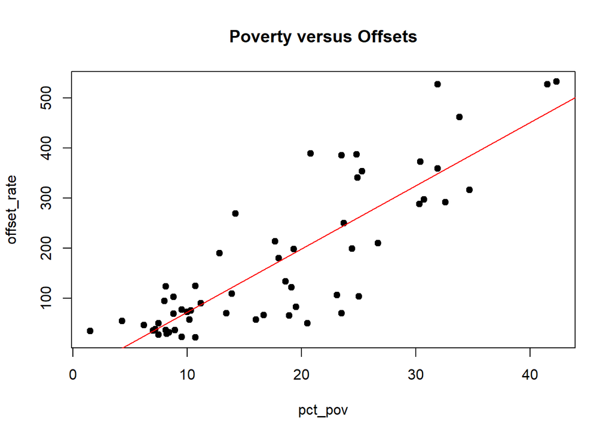

```
##
## Call:
## lm(formula = offset_rate ~ pct_pov, data = ch_debt_census)
##
## Residuals:
##      Min       1Q   Median       3Q      Max
## -172.193  -46.343    0.977   47.237  180.240
##
## Coefficients:
##             Estimate Std. Error t value            Pr(>|t|)
## (Intercept)  -53.622     21.750  -2.465              0.0168 *
## pct_pov       12.605      1.069  11.793 <0.0000000000000002 ***
## ---
## Signif. codes:  0 '***' 0.001 '**' 0.01 '*' 0.05 '.' 0.1 ' ' 1
##
## Residual standard error: 79.61 on 56 degrees of freedom
##   (1 observation deleted due to missingness)
## Multiple R-squared:  0.7129, Adjusted R-squared:  0.7078
## F-statistic: 139.1 on 1 and 56 DF,  p-value: < 0.00000000000000022
```

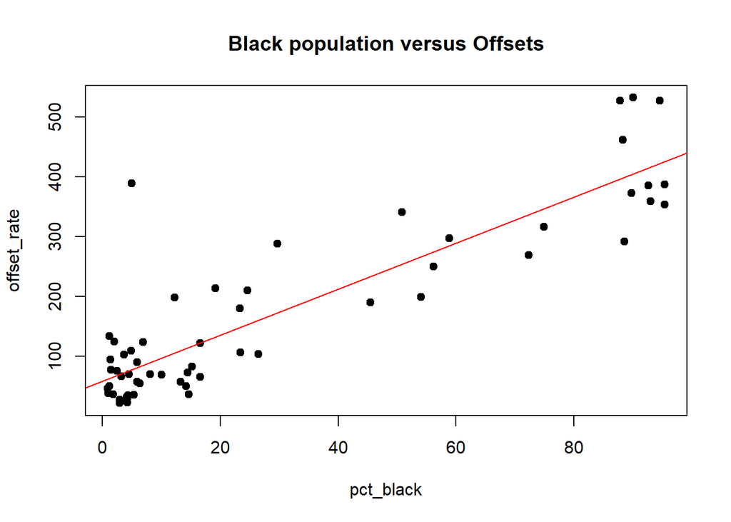

```
##
## Call:
## lm(formula = offset_rate ~ pct_black, data = ch_debt_census)
##
## Residuals:
##     Min      1Q  Median      3Q     Max
## -107.31  -43.29  -24.60   31.09  310.69
##
## Coefficients:
##             Estimate Std. Error t value             Pr(>|t|)
## (Intercept)  58.9121    12.2449   4.811            0.0000117 ***
## pct_black     3.8386     0.2751  13.953 < 0.0000000000000002 ***
## ---
## Signif. codes:  0 '***' 0.001 '**' 0.01 '*' 0.05 '.' 0.1 ' ' 1
##
## Residual standard error: 70.23 on 56 degrees of freedom
##   (1 observation deleted due to missingness)
## Multiple R-squared:  0.7766, Adjusted R-squared:  0.7726
## F-statistic: 194.7 on 1 and 56 DF,  p-value: < 0.00000000000000022
```

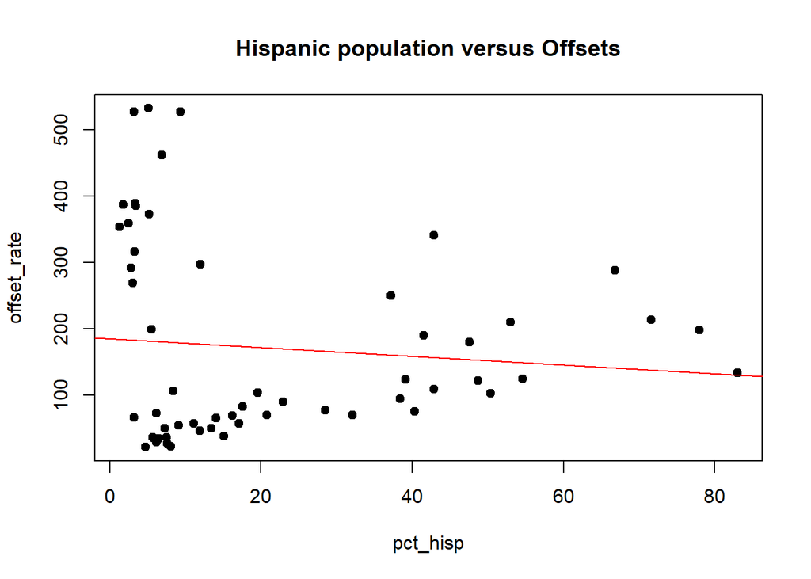

```
##
## Call:
## lm(formula = offset_rate ~ pct_hisp, data = ch_debt_census)
##
## Residuals:
##     Min      1Q  Median      3Q     Max
## -160.30 -119.48  -57.24  103.40  349.87
##
## Coefficients:
##             Estimate Std. Error t value      Pr(>|t|)
## (Intercept) 185.4020    27.4375   6.757 0.00000000871 ***
## pct_hisp     -0.6602     0.9081  -0.727          0.47
## ---
## Signif. codes:  0 '***' 0.001 '**' 0.01 '*' 0.05 '.' 0.1 ' ' 1
##
## Residual standard error: 147.9 on 56 degrees of freedom
##   (1 observation deleted due to missingness)
## Multiple R-squared:  0.00935,    Adjusted R-squared:  -0.00834
## F-statistic: 0.5286 on 1 and 56 DF,  p-value: 0.4702
```

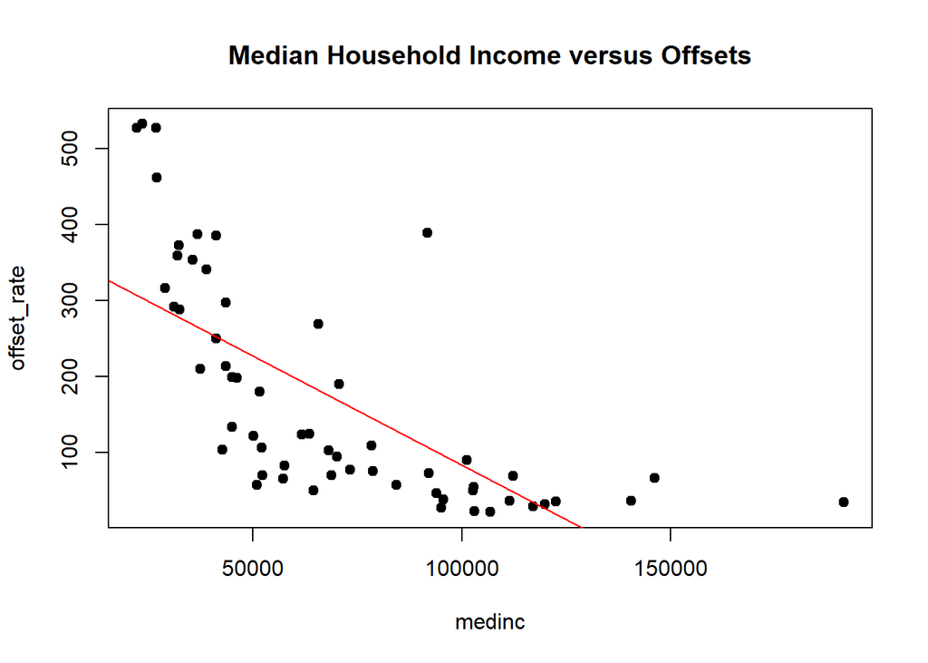

```
##
## Call:
## lm(formula = offset_rate ~ medinc, data = ch_debt_census)
##
## Residuals:
##     Min      1Q  Median      3Q     Max
## -165.87  -69.32  -28.32   65.23  281.86
##
## Coefficients:
##               Estimate Std. Error t value             Pr(>|t|)
## (Intercept) 369.991949  30.680470  12.060 < 0.0000000000000002 ***
## medinc       -0.002867   0.000394  -7.276        0.00000000121 ***
## ---
## Signif. codes:  0 '***' 0.001 '**' 0.01 '*' 0.05 '.' 0.1 ' ' 1
##
## Residual standard error: 106.5 on 56 degrees of freedom
##   (1 observation deleted due to missingness)
## Multiple R-squared:  0.486,  Adjusted R-squared:  0.4768
## F-statistic: 52.94 on 1 and 56 DF,  p-value: 0.00000000121
```

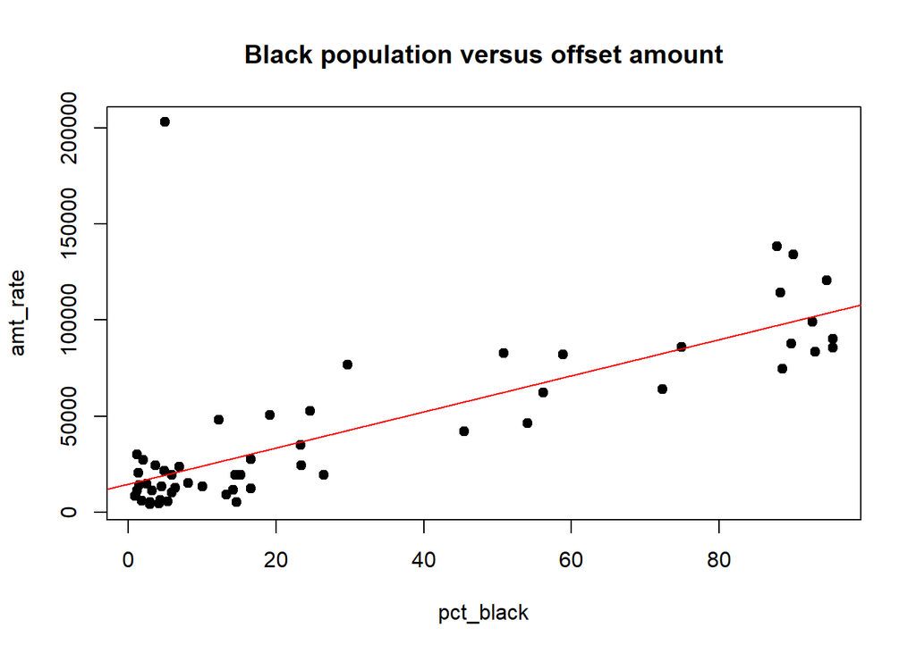

```
##
## Call:
## lm(formula = amt_rate ~ pct_black, data = ch_debt_census)
##
## Residuals:
##    Min     1Q Median     3Q    Max
## -23201 -13706  -7042   3928 183341
##
## Coefficients:
##             Estimate Std. Error t value        Pr(>|t|)
## (Intercept)  14833.8     5042.1   2.942         0.00474 **
## pct_black      938.5      113.3   8.284 0.0000000000264 ***
## ---
## Signif. codes:  0 '***' 0.001 '**' 0.01 '*' 0.05 '.' 0.1 ' ' 1
##
## Residual standard error: 28920 on 56 degrees of freedom
##   (1 observation deleted due to missingness)
## Multiple R-squared:  0.5507, Adjusted R-squared:  0.5426
## F-statistic: 68.63 on 1 and 56 DF,  p-value: 0.00000000002639
```

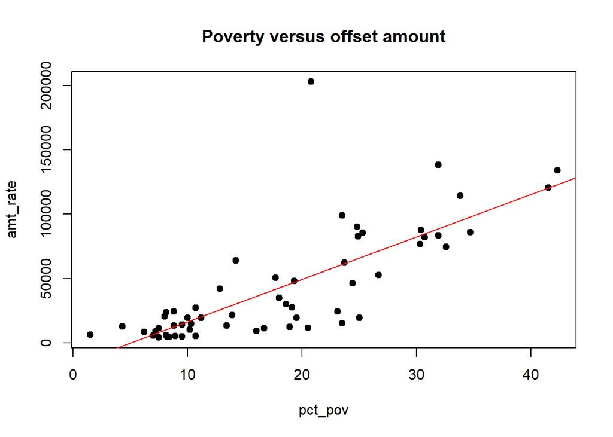

```
##
## Call:
## lm(formula = amt_rate ~ pct_pov, data = ch_debt_census)
##
## Residuals:
##    Min     1Q Median     3Q    Max
## -46396 -12929  -1726  10211 150817
##
## Coefficients:
##             Estimate Std. Error t value        Pr(>|t|)
## (Intercept) -16481.2     7658.2  -2.152          0.0357 *
## pct_pov       3294.8      376.3   8.755 0.0000000000045 ***
## ---
## Signif. codes:  0 '***' 0.001 '**' 0.01 '*' 0.05 '.' 0.1 ' ' 1
##
## Residual standard error: 28030 on 56 degrees of freedom
##   (1 observation deleted due to missingness)
## Multiple R-squared:  0.5778, Adjusted R-squared:  0.5703
## F-statistic: 76.65 on 1 and 56 DF,  p-value: 0.0000000000045
```